# Grinina Yulia ML Project

Задачи:

- Анализ детерминант заработной платы - определить, какие признаки сильнее всего влияют на уровень дохода, с акцентом на анализ гендерного разрыва
- Построение и сравнение прогностических моделей
- Провести кластеризацию - разделить данные на однородные группы и проанализировать их характеристики

# Анализ данных

# Предобработка даных

## Загрузка данных

```python
pip install phik
```

```python
import pandas as pd
import matplotlib.pyplot as plt
import numpy as np
import statsmodels.api as sm
import statsmodels.formula.api as smf
import statsmodels.tools.tools as smt
import statsmodels.stats.diagnostic as smd
import seaborn as sns
from statsmodels.stats.outliers_influence import variance_inflation_factor
from scipy.stats import shapiro
import phik
from phik.report import plot_correlation_matrix
from phik import report
from sklearn.model_selection import train_test_split
from sklearn.linear_model import LogisticRegression
from sklearn.ensemble import RandomForestRegressor
from sklearn.model_selection import train_test_split
from sklearn.preprocessing import LabelEncoder
from sklearn.metrics import mean_squared_error, r2_score, mean_absolute_error
import statsmodels.api as sm
from scipy import stats
from sklearn.tree import DecisionTreeRegressor
from sklearn.ensemble import RandomForestRegressor
import xgboost as xgb
from sklearn.cluster import KMeans
from sklearn.metrics import silhouette_score
import seaborn as sns
import warnings
warnings.filterwarnings('ignore')
from sklearn.decomposition import PCA
from sklearn.preprocessing import StandardScaler
from sklearn.linear_model import LinearRegression, Lasso, Ridge
from sklearn.ensemble import RandomForestRegressor, GradientBoostingRegressor
from xgboost import XGBRegressor
from sklearn.model_selection import train_test_split, cross_val_score, GridSearchCV
```

```python
df=pd.read_csv('short.csv', sep=';')
```

```python
pd.set_option('display.max_columns', None) # вывод всех колонок
```

```python
pd.set_option('display.float_format', '{:.2f}'.format) # избавимся от экспоненциальных даных в описательной статистике
```

```python
df.info()
```

```
<class 'pandas.core.frame.DataFrame'>
RangeIndex: 11820 entries, 0 to 11819
Data columns (total 35 columns):
 #   Column      Non-Null Count  Dtype
---  ------      --------------  -----
 0   Idind       11820 non-null  int64
 1   Psu         11820 non-null  int64
 2   Status      11820 non-null  int64
 3   Bb_Marst    10174 non-null  float64
 4   Bb_Occup08  5172 non-null   float64
 5   Bb_Diplom   10174 non-null  float64
 6   Bb_Age      11820 non-null  object
 7   Bbh5        11820 non-null  int64
 8   Bbi3        4511 non-null   float64
 9   Bbj1        10174 non-null  float64
```

[output cut: 27 more lines]

Исходный набор данных включал демографические, профессиональные, образовательные и психологические показатели, такие как возраст, пол, стаж, образование, уровень дохода, удовлетворенность работой и здоровье, в данных 11820 строк.

```python
df
```

|  | Idind | Psu | Status | Bb_Marst | Bb_Occup08 | Bb_Diplom | Bb_Age | Bbh5 | Bbi3 | Bbj1 | Bbj1_1_1 | Bbj1_1_2 | Bbj1_1_3 | Bbj1_1_4 | Bbj4_1 | Bbj6_2 | Bbj13 | Bbj13_2 | Bbj21_3 | Bbj23 | Bbj24 | Bbj26 | Bbj29c_1 | Bbj29c_2 | Bbj22 | Bbj65 | Bbj66_1 | Bbj72_18a | Bbj72_11 | … |
| --- | --- | --- | --- | --- | --- | --- | --- | --- | --- | --- | --- | --- | --- | --- | --- | --- | --- | --- | --- | --- | --- | --- | --- | --- | --- | --- | --- | --- | --- | --- |
| 0 | 7 | 6 | 3 | 1.00 | NaN | 3.00 | 79 | 2 | 1.00 | 5.00 | NaN | NaN | NaN | NaN | NaN | NaN | NaN | NaN | NaN | NaN | NaN | NaN | NaN | NaN | NaN | 4.00 | 3.00 | 1.00 | 2.00 | … |
| 1 | 92 | 6 | 4 | 2.00 | NaN | 4.00 | 65 | 2 | 3.00 | 5.00 | NaN | NaN | NaN | NaN | NaN | NaN | NaN | NaN | NaN | NaN | NaN | NaN | NaN | NaN | NaN | 2.00 | 4.00 | 5.00 | 2.00 | … |
| 2 | 93 | 6 | 4 | 2.00 | 5.00 | 4.00 | 69,5 | 1 | 3.00 | 1.00 | 2.00 | 2.00 | 2.00 | 2.00 | 13.00 | 48.00 | 80.00 | 35000.00 | 1.00 | 1.00 | 2.00 | 2.00 | 2.00 | 2.00 | 5.00 | 2.00 | 2.00 | 3.00 | 2.00 | … |
| 3 | 95 | 6 | 4 | 5.00 | NaN | 1.00 | 95,5 | 2 | 3.00 | 5.00 | NaN | NaN | NaN | NaN | NaN | NaN | NaN | NaN | NaN | NaN | NaN | NaN | NaN | NaN | NaN | 2.00 | 2.00 | 1.00 | 2.00 | … |
| 4 | 102 | 6 | 4 | 2.00 | NaN | 5.00 | 69 | 2 | 1.00 | 5.00 | NaN | NaN | NaN | NaN | NaN | NaN | NaN | NaN | NaN | NaN | NaN | NaN | NaN | NaN | NaN | 2.00 | 2.00 | 6.00 | 2.00 | … |
| ... | ... | ... | ... | ... | ... | ... | ... | ... | ... | ... | ... | ... | ... | ... | ... | ... | ... | ... | ... | ... | ... | ... | ... | ... | ... | ... | ... | ... | ... | … |
| 11815 | 63954 | 2 | 1 | 5.00 | NaN | 2.00 | 84,5 | 2 | 1.00 | 5.00 | NaN | NaN | NaN | NaN | NaN | NaN | NaN | NaN | NaN | NaN | NaN | NaN | NaN | NaN | NaN | 2.00 | 2.00 | 1.00 | 2.00 | … |
| 11816 | 63955 | 3 | 2 | 3.00 | 5.00 | 5.00 | 20,5 | 2 | 1.00 | 1.00 | 1.00 | 1.00 | 2.00 | 2.00 | 1.00 | 32.00 | 4.00 | 28000.00 | 2.00 | 1.00 | 2.00 | 2.00 | 2.00 | 5.00 | 1.00 | 1.00 | 3.00 | 6.00 | 2.00 | … |
| 11817 | 63956 | 7 | 1 | 1.00 | NaN | 5.00 | 19 | 1 | 2.00 | 5.00 | NaN | NaN | NaN | NaN | NaN | NaN | NaN | NaN | NaN | NaN | NaN | NaN | NaN | NaN | NaN | 2.00 | 4.00 | 2.00 | 2.00 | … |
| 11818 | 63957 | 7 | 1 | 2.00 | 5.00 | 4.00 | 58 | 1 | NaN | 1.00 | 1.00 | 3.00 | 1.00 | 99999997.00 | 13.00 | 48.00 | 300.00 | 26000.00 | 2.00 | 2.00 | 2.00 | 2.00 | 1.00 | 2.00 | 4.00 | 2.00 | 2.00 | 5.00 | 1.00 | … |
| 11819 | 63958 | 7 | 1 | 5.00 | NaN | 4.00 | 66 | 2 | NaN | 5.00 | NaN | NaN | NaN | NaN | NaN | NaN | NaN | NaN | NaN | NaN | NaN | NaN | NaN | NaN | NaN | 4.00 | 5.00 | 2.00 | 2.00 | … |

11820 rows × 35 columns

```python
df.rename(columns = {'Idind': 'id', 'Psu':'region', 'Status': 'locality', 'Bb_Marst': 'marital_status', \
                     'Bb_Occup08': 'occupation', 'Bb_Diplom': 'edu', 'Bb_Age': 'age', 'Bbh5': 'male', 'Bbi3': 'birthplace', \
                    'Bbj1': 'employment', 'Bbj1_1_1': 'job_satisfaction', 'Bbj1_1_2': 'labour_conditions_satisfaction', \
                    'Bbj1_1_3': 'salary_satisfaction', 'Bbj1_1_4': 'promotion_satisfaction', 'Bbj4_1': 'industry', \
                    'Bbj6_2': 'work_schedule', 'Bbj13': 'organization_size', 'Bbj13_2': 'salary', 'Bbj21_3': 'hazardous_industry', \
                    'Bbj23': 'state_owner', 'Bbj24': 'foreign_owner', 'Bbj26': 'self_owner', 'Bbj29c_1': 'management_trust', \
                    'Bbj29c_2': 'colleagues_trust', 'Bbj22': 'new_job_confidence', 'Bbj65': 'life_satisfaction', \
                    'Bbj66_1': 'financial_situation_satisfaction', 'Bbj72_18a': 'diplom', 'Bbj72_11': 'courses', \
                    'Bbj260': 'foreign_language', 'Bbj72_172': 'kids', 'Bbj161_3y': 'experience', 'Bbm3': 'health', \
                    'Bbm20_7': 'disability', 'Bbm131': 'depression'}, inplace = True) # переименуем колонки для читабельности
```

```python
df
```

|  | id | region | locality | marital_status | occupation | edu | age | male | birthplace | employment | job_satisfaction | labour_conditions_satisfaction | salary_satisfaction | promotion_satisfaction | industry | work_schedule | organization_size | salary | hazardous_industry | state_owner | foreign_owner | self_owner | management_trust | colleagues_trust | new_job_confidence | life_satisfaction | financial_situation_satisfaction | diplom | courses | … |
| --- | --- | --- | --- | --- | --- | --- | --- | --- | --- | --- | --- | --- | --- | --- | --- | --- | --- | --- | --- | --- | --- | --- | --- | --- | --- | --- | --- | --- | --- | --- |
| 0 | 7 | 6 | 3 | 1.00 | NaN | 3.00 | 79 | 2 | 1.00 | 5.00 | NaN | NaN | NaN | NaN | NaN | NaN | NaN | NaN | NaN | NaN | NaN | NaN | NaN | NaN | NaN | 4.00 | 3.00 | 1.00 | 2.00 | … |
| 1 | 92 | 6 | 4 | 2.00 | NaN | 4.00 | 65 | 2 | 3.00 | 5.00 | NaN | NaN | NaN | NaN | NaN | NaN | NaN | NaN | NaN | NaN | NaN | NaN | NaN | NaN | NaN | 2.00 | 4.00 | 5.00 | 2.00 | … |
| 2 | 93 | 6 | 4 | 2.00 | 5.00 | 4.00 | 69,5 | 1 | 3.00 | 1.00 | 2.00 | 2.00 | 2.00 | 2.00 | 13.00 | 48.00 | 80.00 | 35000.00 | 1.00 | 1.00 | 2.00 | 2.00 | 2.00 | 2.00 | 5.00 | 2.00 | 2.00 | 3.00 | 2.00 | … |
| 3 | 95 | 6 | 4 | 5.00 | NaN | 1.00 | 95,5 | 2 | 3.00 | 5.00 | NaN | NaN | NaN | NaN | NaN | NaN | NaN | NaN | NaN | NaN | NaN | NaN | NaN | NaN | NaN | 2.00 | 2.00 | 1.00 | 2.00 | … |
| 4 | 102 | 6 | 4 | 2.00 | NaN | 5.00 | 69 | 2 | 1.00 | 5.00 | NaN | NaN | NaN | NaN | NaN | NaN | NaN | NaN | NaN | NaN | NaN | NaN | NaN | NaN | NaN | 2.00 | 2.00 | 6.00 | 2.00 | … |
| ... | ... | ... | ... | ... | ... | ... | ... | ... | ... | ... | ... | ... | ... | ... | ... | ... | ... | ... | ... | ... | ... | ... | ... | ... | ... | ... | ... | ... | ... | … |
| 11815 | 63954 | 2 | 1 | 5.00 | NaN | 2.00 | 84,5 | 2 | 1.00 | 5.00 | NaN | NaN | NaN | NaN | NaN | NaN | NaN | NaN | NaN | NaN | NaN | NaN | NaN | NaN | NaN | 2.00 | 2.00 | 1.00 | 2.00 | … |
| 11816 | 63955 | 3 | 2 | 3.00 | 5.00 | 5.00 | 20,5 | 2 | 1.00 | 1.00 | 1.00 | 1.00 | 2.00 | 2.00 | 1.00 | 32.00 | 4.00 | 28000.00 | 2.00 | 1.00 | 2.00 | 2.00 | 2.00 | 5.00 | 1.00 | 1.00 | 3.00 | 6.00 | 2.00 | … |
| 11817 | 63956 | 7 | 1 | 1.00 | NaN | 5.00 | 19 | 1 | 2.00 | 5.00 | NaN | NaN | NaN | NaN | NaN | NaN | NaN | NaN | NaN | NaN | NaN | NaN | NaN | NaN | NaN | 2.00 | 4.00 | 2.00 | 2.00 | … |
| 11818 | 63957 | 7 | 1 | 2.00 | 5.00 | 4.00 | 58 | 1 | NaN | 1.00 | 1.00 | 3.00 | 1.00 | 99999997.00 | 13.00 | 48.00 | 300.00 | 26000.00 | 2.00 | 2.00 | 2.00 | 2.00 | 1.00 | 2.00 | 4.00 | 2.00 | 2.00 | 5.00 | 1.00 | … |
| 11819 | 63958 | 7 | 1 | 5.00 | NaN | 4.00 | 66 | 2 | NaN | 5.00 | NaN | NaN | NaN | NaN | NaN | NaN | NaN | NaN | NaN | NaN | NaN | NaN | NaN | NaN | NaN | 4.00 | 5.00 | 2.00 | 2.00 | … |

11820 rows × 35 columns

```python
df.info()
```

```
<class 'pandas.core.frame.DataFrame'>
RangeIndex: 11820 entries, 0 to 11819
Data columns (total 35 columns):
 #   Column                            Non-Null Count  Dtype
---  ------                            --------------  -----
 0   id                                11820 non-null  int64
 1   region                            11820 non-null  int64
 2   locality                          11820 non-null  int64
 3   marital_status                    10174 non-null  float64
 4   occupation                        5172 non-null   float64
 5   edu                               10174 non-null  float64
 6   age                               11820 non-null  object
 7   male                              11820 non-null  int64
 8   birthplace                        4511 non-null   float64
 9   employment                        10174 non-null  float64
```

[output cut: 27 more lines]

```python
df['age'] = df['age'].str.replace(',', '.').astype(float) # приводим количественные показатели к корректному формату
```

```python
df[df['occupation'] == 1]['male'].value_counts()
```

```
male
1    154
2    130
Name: count, dtype: int64
```

## Работа с данными

### Заработная плата

```python
df['salary'].describe()
```

```
count       4681.00
mean     7344408.20
std     26015756.47
min            0.00
25%        25000.00
50%        37000.00
75%        58000.00
max     99999999.00
Name: salary, dtype: float64
```

```python
problem = len(df[(df['salary'] == 99999999.00) | (df['salary'] == 99999998.00) | (df['salary'] == 99999997.00) | (df['salary'] == 99999996.00)]) # посмотрим в скольких наблюдениях артефакты
workers = len(df[(df['employment'] == 1)]) # выведем количество человек, которые работают
known_salary = len(df[(df['employment'] == 1) & (df['salary'].isna() == False) & (df['salary'] != 99999999.00) & (df['salary'] != 99999998.00) & (df['salary'] != 99999997.00) & (df['salary'] != 99999996.00)]) # выведем количество людей, которые работают и у них известна зп

print(f'''
Количество наблюдений с артефактами: {problem}
Количество работающих человек в выборке: {workers}
Количество работающих, без известной з/п: {workers - known_salary}, доля: {round(((workers - known_salary)/workers)*100, 2)}%
Количество человек с нулевой з/п: {len(df[df['salary'] == 0])}
Количество человек в отпуске: {len(df[(df['employment'] != 1) & (df['employment'].isna() == False) & (df['employment'] != 99999999.00) & (df['employment'] != 99999998.00) & (df['employment'] != 99999997.00) & (df['employment'] != 99999996.00)])}

''')
```

```
Количество наблюдений с артефактами: 342
Количество работающих человек в выборке: 5058
Количество работающих, без известной з/п: 807, доля: 15.95%
Количество человек с нулевой з/п: 27
Количество человек в отпуске: 5106
```

```python
df['employment'].value_counts()
```

```
employment
1.00           5058
5.00           4992
2.00             91
3.00             15
99999998.00       8
4.00              8
99999997.00       2
Name: count, dtype: int64
```

```python
# удалим строки с неизвестной зп и безработных
clean_df = df.copy()
clean_df = clean_df[clean_df['salary'].isna() == False].reset_index(drop=True)
clean_df = clean_df[(clean_df['salary'] != 99999999.00) & (clean_df['salary'] != 99999998.00) & (clean_df['salary'] != 99999997.00) & (clean_df['salary'] != 99999996.00)].reset_index(drop=True)
clean_df = clean_df[clean_df['employment'] != 5]
```

```
Медианная зп у мужчин: 40000.0
Средняя зп у мужчин: 48472.9
count     1991.00
mean     48472.86
std      29873.26
min          0.00
25%      30000.00
50%      40000.00
75%      60000.00
max     300000.00
Name: salary, dtype: float64
```

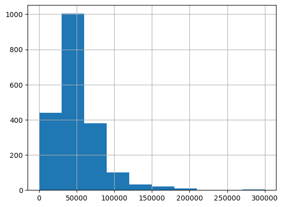

```python
# зп мужчин
print(f'Медианная зп у мужчин: {clean_df[clean_df['male'] == 1]['salary'].median()}')
print(f'Средняя зп у мужчин: {round(clean_df[clean_df['male'] == 1]['salary'].mean(), 1)}')
print(clean_df[clean_df['male'] == 1]['salary'].describe())
clean_df[clean_df['male'] == 1]['salary'].hist();
```

```
Медианная зп у женщин: 30000.0
Средняя зп у женщин: 35207.0
count     2348.00
mean     35207.04
std      22104.61
min          0.00
25%      21000.00
50%      30000.00
75%      43000.00
max     300000.00
Name: salary, dtype: float64
```

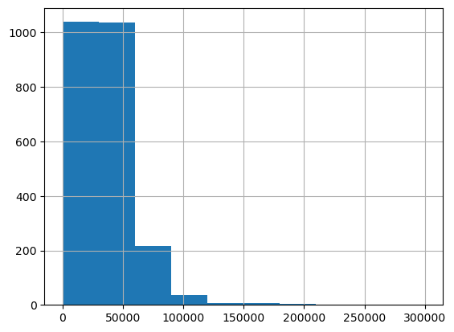

```python
# средняя зп женщин
print(f'Медианная зп у женщин: {clean_df[clean_df['male'] == 2]['salary'].median()}')
print(f'Средняя зп у женщин: {round(clean_df[clean_df['male'] == 2]['salary'].mean(), 1)}')
print(clean_df[clean_df['male'] == 2]['salary'].describe())
clean_df[clean_df['male'] == 2]['salary'].hist();
```

```python
# удалим строки с нулевой зп
clean_df = clean_df[clean_df['salary'] != 0].reset_index(drop=True)
```

```
count     4312.00
mean     41552.78
std      26668.19
min        600.00
25%      25000.00
50%      35000.00
75%      50000.00
max     300000.00
Name: salary, dtype: float64
```

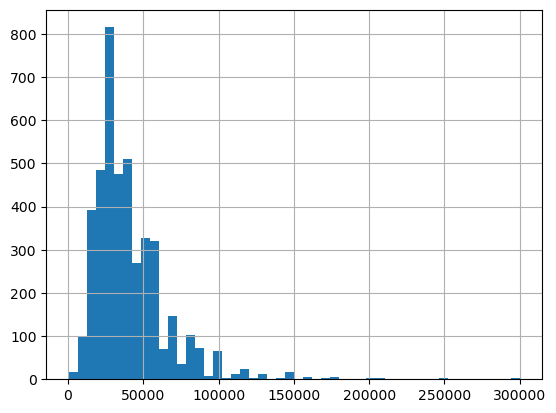

```python
print(clean_df['salary'].describe())
clean_df['salary'].hist(bins=50);
```

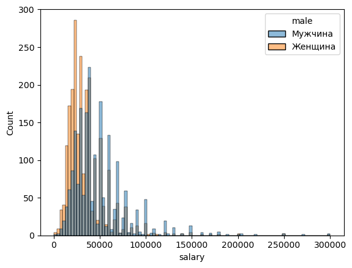

```python
male_df = clean_df.copy()
male_df['male'] = male_df['male'].apply(lambda x: 'Мужчина' if x == 1 else 'Женщина')
sns.histplot(data=male_df, x='salary', hue='male', color='black')
plt.show()
```

```python
# создадим функцию для подсчёта жестких выбросов
def emissions(df, column):
    '''Функция для подсчёта процента выбросов в столбце'''
    Q1 = df[column].quantile(0.25)
    Q3 = df[column].quantile(0.75)
    IQR = Q3 - Q1

    lower_bound = Q1 - 3 * IQR
    upper_bound = Q3 + 3 * IQR

    return f"процент выбросов составляет {round(len(df[(df[column] <= lower_bound) | (df[column] >= upper_bound)])/df.shape[0]*100, 2)}"
```

```python
def remove_heavy_emissions(df, column):
    '''Функция для удаления выбросов через межквартильный размах'''
    Q1 = df[column].quantile(0.25)
    Q3 = df[column].quantile(0.75)
    IQR = Q3 - Q1

    lower_bound = Q1 - 3 * IQR
    upper_bound = Q3 + 3 * IQR

    return df[(df[column] >= lower_bound) & (df[column] <= upper_bound)].reset_index(drop=True)
```

```python
emissions(clean_df, 'salary')
```

```
'процент выбросов составляет 1.48'
```

```python
clean_df['log_salary'] = np.log(clean_df['salary']) # для минсеровского уравнения возьмём логарифм зп
```

```
процент выбросов составляет 0.09
count   4312.00
mean      10.47
std        0.56
min        6.40
25%       10.13
50%       10.46
75%       10.82
max       12.61
Name: log_salary, dtype: float64
```

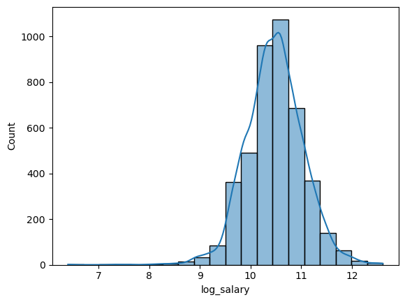

```python
print(emissions(clean_df, 'log_salary'))
print(clean_df['log_salary'].describe())
sns.histplot(clean_df['log_salary'], kde=True, bins=20); # распределение
```

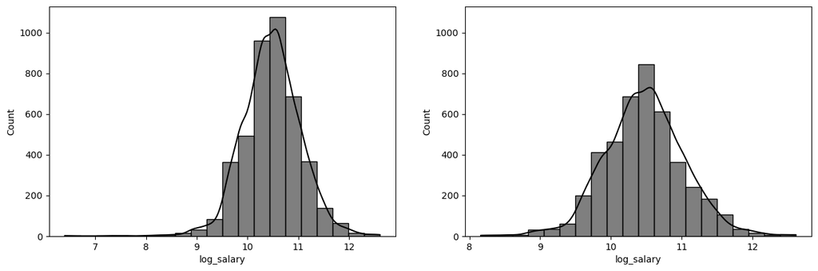

```python
plt.figure(figsize=(15, 10))
ax1 = plt.subplot(2, 2, 1)
sns.histplot(clean_df['log_salary'], kde=True, bins=20, ax=ax1, color='black')
ax2 = plt.subplot(2, 2, 2, sharey = ax1)
clean_df = remove_heavy_emissions(clean_df, 'log_salary')
sns.histplot(clean_df['log_salary'], kde=True, bins=20, ax=ax2, color='black')
plt.show()
```

```python
# Создаём копию данных и переименовываем значения
gender_df = clean_df.copy()
# Считаем количество мужчин и женщин
gender_counts = male_df['male'].value_counts()
print(gender_counts)
```

```
male
Женщина    2324
Мужчина    1988
Name: count, dtype: int64
```

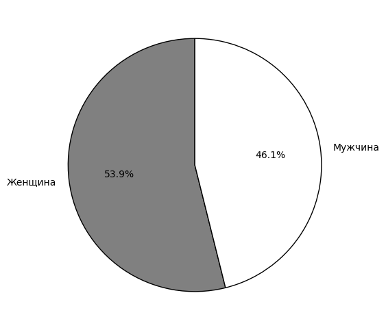

```python
plt.figure(figsize=(6, 6))  # Размер графика
plt.pie(
    gender_counts,               # Данные
    labels=gender_counts.index,  # Подписи (Мужчина/Женщина)
    autopct='%.1f%%',            # Проценты с 1 десятичным знаком
    colors=['grey', 'white'], # Цвета
    startangle=90,               # Поворот на 90 градусов
    wedgeprops={'linewidth': 1, 'edgecolor': 'black'},
    # legend = True# Границы секторов
)
# plt.title('Распределение мужчин и женщин')
plt.show()
```

### Предобработка

```python
clean_df.info()
```

```
<class 'pandas.core.frame.DataFrame'>
RangeIndex: 4308 entries, 0 to 4307
Data columns (total 36 columns):
 #   Column                            Non-Null Count  Dtype
---  ------                            --------------  -----
 0   id                                4308 non-null   int64
 1   region                            4308 non-null   int64
 2   locality                          4308 non-null   int64
 3   marital_status                    4308 non-null   float64
 4   occupation                        4308 non-null   float64
 5   edu                               4308 non-null   float64
 6   age                               4308 non-null   float64
 7   male                              4308 non-null   int64
 8   birthplace                        1706 non-null   float64
 9   employment                        4308 non-null   float64
```

[output cut: 28 more lines]

```python
def null_transform(columns, data): # создадим функцию для удаления артефактов
    for i in columns:
        for n in (99999996.00, 99999997.00, 99999999.00, 99999998.00):
            data.loc[data[i] == n, i] = np.nan
```

```python
col = list(clean_df.columns.values)
null_transform(col, clean_df)
```

```python
clean_df.describe()
```

|  | id | region | locality | marital_status | occupation | edu | age | male | birthplace | employment | job_satisfaction | labour_conditions_satisfaction | salary_satisfaction | promotion_satisfaction | industry | work_schedule | organization_size | salary | hazardous_industry | state_owner | foreign_owner | self_owner | management_trust | colleagues_trust | new_job_confidence | life_satisfaction | financial_situation_satisfaction | diplom | courses | … |
| --- | --- | --- | --- | --- | --- | --- | --- | --- | --- | --- | --- | --- | --- | --- | --- | --- | --- | --- | --- | --- | --- | --- | --- | --- | --- | --- | --- | --- | --- | --- |
| count | 4308.00 | 4308.00 | 4308.00 | 4300.00 | 4299.00 | 4300.00 | 4308.00 | 4308.00 | 1702.00 | 4308.00 | 4284.00 | 4288.00 | 4286.00 | 4157.00 | 4292.00 | 3949.00 | 2982.00 | 4308.00 | 4259.00 | 4189.00 | 4168.00 | 4303.00 | 4215.00 | 4239.00 | 4211.00 | 4274.00 | 4285.00 | 4307.00 | 4307.00 | … |
| mean | 42162.31 | 17.85 | 2.01 | 2.32 | 4.60 | 4.92 | 44.20 | 1.54 | 1.91 | 1.02 | 2.10 | 2.08 | 2.81 | 2.40 | 10.82 | 42.82 | 451.29 | 41589.74 | 1.87 | 1.56 | 1.98 | 1.97 | 2.03 | 1.91 | 2.87 | 2.43 | 3.29 | 6.91 | 1.94 | … |
| std | 17286.66 | 11.51 | 1.14 | 1.08 | 2.48 | 1.01 | 12.18 | 0.50 | 0.92 | 0.19 | 0.75 | 0.78 | 1.08 | 0.98 | 5.67 | 10.75 | 2490.75 | 26652.95 | 0.34 | 0.50 | 0.14 | 0.16 | 0.81 | 0.68 | 1.18 | 0.89 | 1.06 | 3.42 | 0.24 | … |
| min | 93.00 | 1.00 | 1.00 | 1.00 | 0.00 | 1.00 | 16.00 | 1.00 | 1.00 | 1.00 | 1.00 | 1.00 | 1.00 | 1.00 | 1.00 | 4.00 | 1.00 | 3500.00 | 1.00 | 1.00 | 1.00 | 1.00 | 1.00 | 1.00 | 1.00 | 1.00 | 1.00 | 1.00 | 1.00 | … |
| 25% | 30271.75 | 7.00 | 1.00 | 2.00 | 3.00 | 4.00 | 35.00 | 1.00 | 1.00 | 1.00 | 2.00 | 2.00 | 2.00 | 2.00 | 7.00 | 40.00 | 13.00 | 25000.00 | 2.00 | 1.00 | 2.00 | 2.00 | 2.00 | 1.00 | 2.00 | 2.00 | 2.00 | 5.00 | 2.00 | … |
| 50% | 45599.00 | 18.00 | 2.00 | 2.00 | 4.00 | 5.00 | 44.00 | 2.00 | 2.00 | 1.00 | 2.00 | 2.00 | 3.00 | 2.00 | 11.00 | 40.00 | 36.00 | 35000.00 | 2.00 | 2.00 | 2.00 | 2.00 | 2.00 | 2.00 | 3.00 | 2.00 | 3.00 | 6.00 | 2.00 | … |
| 75% | 58213.00 | 28.00 | 3.00 | 3.00 | 7.00 | 6.00 | 53.00 | 2.00 | 3.00 | 1.00 | 2.00 | 2.00 | 4.00 | 3.00 | 14.00 | 48.00 | 120.00 | 50000.00 | 2.00 | 2.00 | 2.00 | 2.00 | 2.00 | 2.00 | 4.00 | 3.00 | 4.00 | 10.00 | 2.00 | … |
| max | 63957.00 | 38.00 | 4.00 | 6.00 | 9.00 | 6.00 | 86.50 | 2.00 | 3.00 | 4.00 | 5.00 | 5.00 | 5.00 | 5.00 | 31.00 | 120.00 | 90000.00 | 300000.00 | 2.00 | 2.00 | 2.00 | 2.00 | 5.00 | 5.00 | 5.00 | 5.00 | 5.00 | 17.00 | 2.00 | … |

```python
clean_df.isna().sum()/len(clean_df)*100
```

```
id                                  0.00
region                              0.00
locality                            0.00
marital_status                      0.19
occupation                          0.21
edu                                 0.19
age                                 0.00
male                                0.00
birthplace                         60.49
employment                          0.00
job_satisfaction                    0.56
labour_conditions_satisfaction      0.46
salary_satisfaction                 0.51
promotion_satisfaction              3.51
industry                            0.37
work_schedule                       8.33
organization_size                  30.78
salary                              0.00
hazardous_industry                  1.14
state_owner                         2.76
foreign_owner                       3.25
self_owner                          0.12
management_trust                    2.16
colleagues_trust                    1.60
new_job_confidence                  2.25
life_satisfaction                   0.79
financial_situation_satisfaction    0.53
diplom                              0.02
courses                             0.02
foreign_language                    0.26
kids                               24.98
experience                          6.41
health                              0.70
disability                          0.00
depression                          0.74
log_salary                          0.00
dtype: float64
```

### График работы

```
count   3949.00
mean      42.82
std       10.75
min        4.00
25%       40.00
50%       40.00
75%       48.00
max      120.00
Name: work_schedule, dtype: float64
Пропуски: 359
```

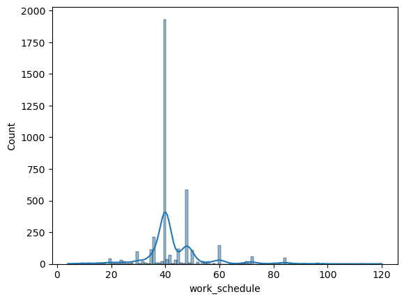

```python
print(clean_df['work_schedule'].describe())
print(f'Пропуски: {clean_df['work_schedule'].isna().sum()}')
sns.histplot(clean_df['work_schedule'], kde=True);
```

```python
print(f'Медианный график работы женщины: {clean_df[clean_df['male'] == 2]['work_schedule'].mean()} ч/нед')
print(f'Медианный график работы мужчины: {clean_df[clean_df['male'] == 1]['work_schedule'].mean()} ч/нед')
```

```
Медианный график работы женщины: 40.79734675205855 ч/нед
Медианный график работы мужчины: 45.31707317073171 ч/нед
```

```python
gender_df = clean_df.copy()

gender_counts = male_df['male'].value_counts()
print(gender_counts)
```

```
male
Женщина    2324
Мужчина    1988
Name: count, dtype: int64
```

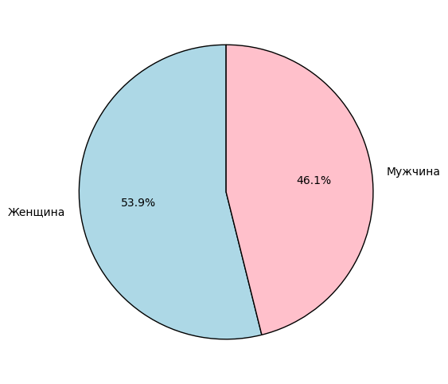

```python
plt.figure(figsize=(6, 6))
plt.pie(
    gender_counts,
    labels=gender_counts.index,
    autopct='%.1f%%',
    colors=['lightblue', 'pink'],
    startangle=90,
    wedgeprops={'linewidth': 1, 'edgecolor': 'black'}
)
# plt.title('Распределение мужчин и женщин')
plt.show()
```

```python
clean_df['work_schedule'] = clean_df['work_schedule'].fillna(clean_df['work_schedule'].median())
```

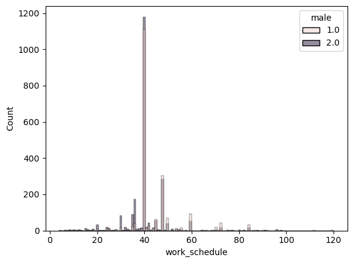

```python
sns.histplot(data=clean_df, x='work_schedule', hue='male')
```

### Возраст

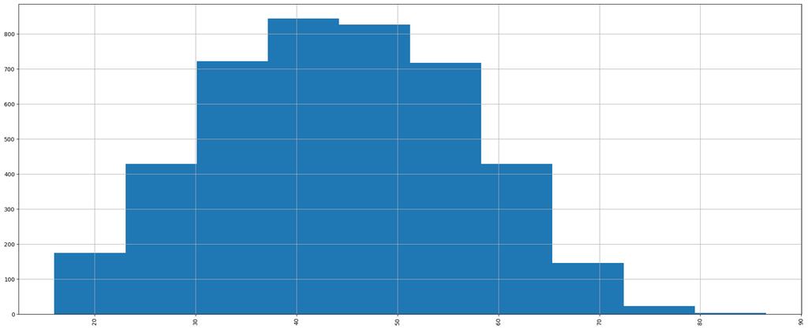

```python
# возраст
clean_df['age'].sort_values().hist(figsize=(25,10))
plt.xticks(rotation=90)
plt.show()
```

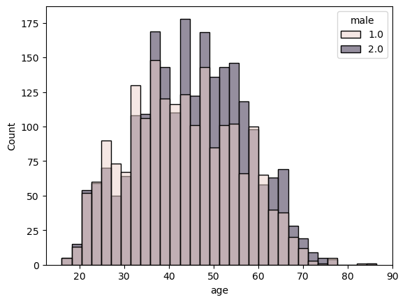

```python
sns.histplot(data=clean_df, x='age', hue='male')
```

```python
clean_df['age'].describe()
```

```
count   4308.00
mean      44.20
std       12.18
min       16.00
25%       35.00
50%       44.00
75%       53.00
max       86.50
Name: age, dtype: float64
```

```python
emissions(clean_df, 'age')
```

```
'процент выбросов составляет 0.0'
```

```python
clean_df['age2'] = clean_df['age']**2 # добавим квадрат возраста для дальнейшей спецификации
```

### Дети

```python
clean_df['kids'].describe()
```

```
count   3232.00
mean       1.73
std        0.82
min        1.00
25%        1.00
50%        2.00
75%        2.00
max       11.00
Name: kids, dtype: float64
```

```python
emissions(clean_df, 'kids')
```

```
'процент выбросов составляет 0.6'
```

```python
clean_df['kids'].value_counts()
```

```
kids
2.00     1424
1.00     1410
3.00      320
4.00       52
5.00       12
7.00        6
6.00        6
11.00       1
9.00        1
Name: count, dtype: int64
```

```python
# удалим из рассмотрения экстремальные значени
clean_df = clean_df[clean_df['kids'] != 11]
clean_df = clean_df[clean_df['kids'] != 9]
```

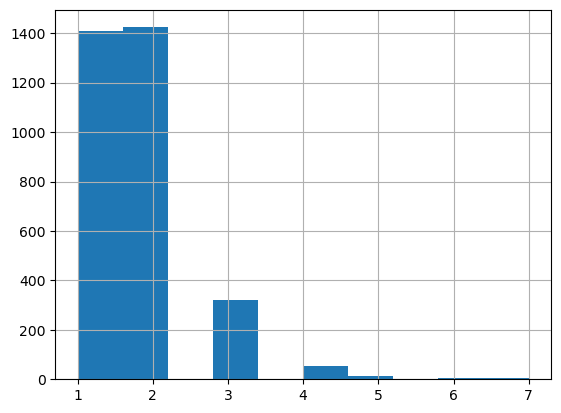

```python
clean_df['kids'].hist()
```

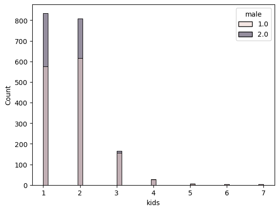

```python
sns.histplot(data=clean_df, x='kids', hue='male')
```

```python
clean_df['kids'].isna().sum()/len(clean_df)*100
```

```
24.988388295401766
```

```python
clean_df['kids'] = clean_df['kids'].fillna(0)
```

### Стаж

```python
clean_df['experience'].describe()
```

```
count   4030.00
mean      20.80
std       12.26
min        0.00
25%       11.00
50%       20.00
75%       30.00
max       69.00
Name: experience, dtype: float64
```

```python
emissions(clean_df, 'experience')
```

```
'процент выбросов составляет 0.0'
```

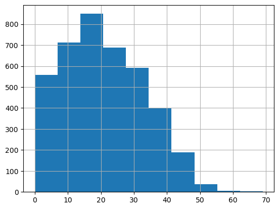

```python
clean_df['experience'].hist()
```

```python
clean_df['experience'].isna().sum()
```

```
276
```

```python
# Создаем словарь {возраст: средний стаж} - так как есть сильная корреляция с возрастом, то заменяем пропуски на среднее для соответ-го возраста
mean_experience_by_age = clean_df.groupby('age')['experience'].mean().to_dict()
clean_df['experience'] = clean_df.apply(
    lambda row: mean_experience_by_age.get(row['age'], row['experience'])
    if pd.isna(row['experience'])
    else row['experience'],
    axis=1
)
```

```python
clean_df['experience'].isna().sum() # посчитаем кол-во пропусков
```

```
5
```

```python
clean_df['experience'] = clean_df['experience'].fillna(clean_df['experience'].median())
```

```python
clean_df['experience^2'] = clean_df['experience']**2
```

### Размер организации

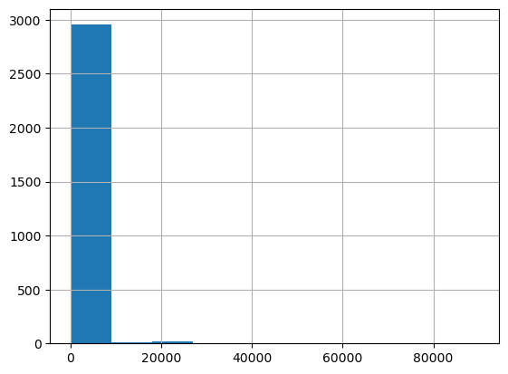

```python
clean_df['organization_size'].hist()
```

```python
print(clean_df['organization_size'].describe()) # не берём переменную из-за большого кол-ва пропусков
clean_df['organization_size'].isna().sum()/len(clean_df)*100
```

```
count    2982.00
mean      451.29
std      2490.75
min         1.00
25%        13.00
50%        36.00
75%       120.00
max     90000.00
Name: organization_size, dtype: float64
```

```
30.747793776126336
```

### dummy-переменные

#### Регион проживания

```python
clean_df.groupby('region').mean()['salary'].sort_values(ascending=False).head(5)
```

```
region
2.00    64632.02
36.00   61751.80
3.00    52353.17
5.00    49837.14
1.00    49643.18
Name: salary, dtype: float64
```

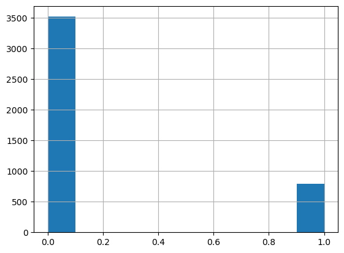

```python
# разделим регион на москву, московскую область и Санкт-Петербург и остальное
clean_df['capital'] = clean_df['region'].apply(lambda x: 1 if x == 1 or x== 2 or x== 3 else 0)
clean_df['capital'].hist()
```

#### Место жительства

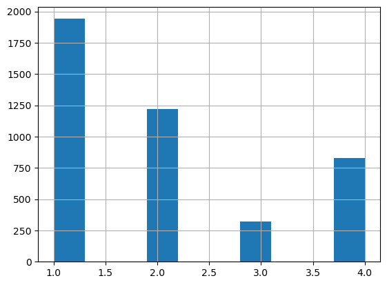

```python
clean_df['locality'].hist(bins=10) # место жительства
```

```python
# тип населённого пункта, базовая переменная - село
clean_df['city'] = clean_df['locality'].apply(lambda x: 1 if x == 1 or x== 2 else 0) # областной центр или город
clean_df['urban_type'] = clean_df['locality'].apply(lambda x: 1 if x == 3 else 0) # посёлок городского типа
```

#### Семейный статус

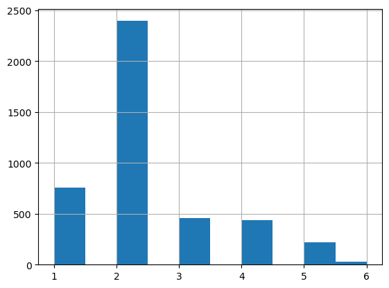

```python
clean_df['marital_status'].hist() # семейный статус
```

```python
# состояние в браке
clean_df['marital_status'] = clean_df['marital_status'].apply(lambda x: 1 if x == 2 or x == 6 else 0)
```

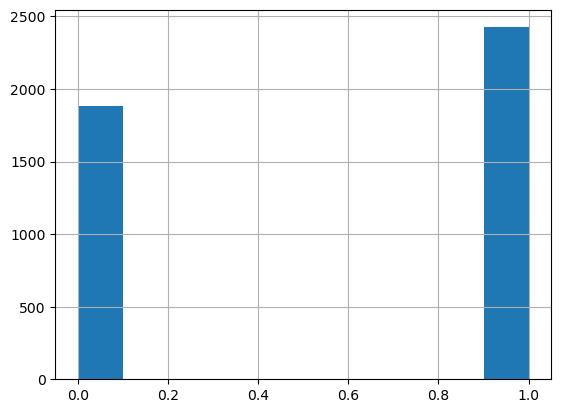

```python
clean_df['marital_status'].hist()
```

```python
clean_df['marital_status'].value_counts() # кол-во респондентов по группам
```

```
marital_status
1    2425
0    1881
Name: count, dtype: int64
```

#### Профессиональная группа

```python
# профессиональная группа
clean_df['occupation'].value_counts()
```

```
occupation
3.00    942
2.00    766
5.00    752
7.00    503
8.00    490
9.00    330
4.00    249
1.00    236
0.00     26
6.00      3
Name: count, dtype: int64
```

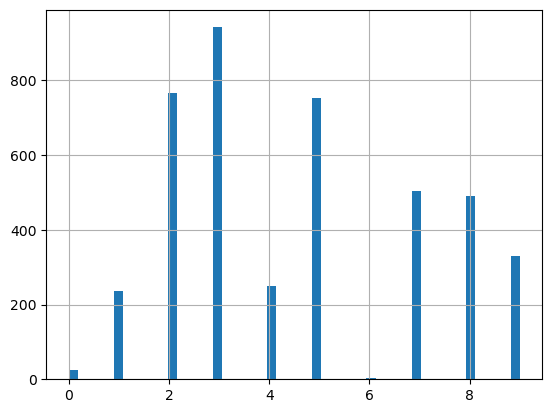

```python
clean_df['occupation'].hist(bins=50)
```

```python
print('Медианная зп')
display(clean_df.groupby('occupation').median()['salary'].sort_values(ascending=False)) # рассмотрим медианную зп по сферам
print()
print('Средняя зп')
clean_df.groupby('occupation').mean()['salary'].sort_values(ascending=False) # рассмотрим среднюю зп по сферам
```

```
Медианная зп
```

```
occupation
0.00   55000.00
1.00   50000.00
2.00   40000.00
7.00   40000.00
8.00   40000.00
3.00   37000.00
4.00   32000.00
5.00   28000.00
6.00   25000.00
9.00   24000.00
Name: salary, dtype: float64
```

```
Средняя зп
```

```
occupation
0.00   70411.54
1.00   59927.08
2.00   47547.46
8.00   47039.63
7.00   44036.88
3.00   41081.16
4.00   36390.36
5.00   31683.14
9.00   28804.25
6.00   28333.33
Name: salary, dtype: float64
```

Наибольшая медианная заработная плата у чиновкников и высшего/среднего руководства, а также у специалистов высшего уровня квалификации и квалифицированных рабочих ручного и масшинного труда

```python
clean_df = clean_df[clean_df['occupation'] != 0].reset_index(drop=True) # убираем из выборки военнослужащих из-за другого механизма форитрования з/п
```

```python
clean_df['occupation'].isna().sum() # проверяем пропуски
```

```
9
```

```python
# заполним пропуски
clean_df.loc[(clean_df['occupation'].isna()) & ((clean_df['industry'] == 18) | (clean_df['industry'] == 7)| (clean_df['industry'] == 12)| (clean_df['industry'] == 13)),'occupation'] = 5
clean_df.loc[(clean_df['occupation'].isna()) & ((clean_df['industry'] == 4) | (clean_df['industry'] == 5)), 'occupation'] = 8
clean_df.loc[(clean_df['occupation'].isna()) & (clean_df['industry'] == 6), 'occupation'] = 7
clean_df = clean_df[clean_df['occupation'].isna() == False].reset_index(drop=True)
```

```python
# разделим на управляющие позиции, база - неуправленцы
clean_df['high_qualifited'] = clean_df['occupation'].apply(lambda x: 1 if x == 1 else 0)
```

```python
clean_df['high_qualifited'].value_counts()
```

```
high_qualifited
0    4042
1     236
Name: count, dtype: int64
```

```python
print(f'Доля женщин на руководящей позиции: {clean_df[clean_df['male'] == 2]['high_qualifited'].sum()/clean_df['high_qualifited'].sum()}')
print(f'Доля мужчин на руководящей позиции: {clean_df[clean_df['male'] == 1]['high_qualifited'].sum()/clean_df['high_qualifited'].sum()}')
```

```
Доля женщин на руководящей позиции: 0.4830508474576271
Доля мужчин на руководящей позиции: 0.5169491525423728
```

#### Уровень образования

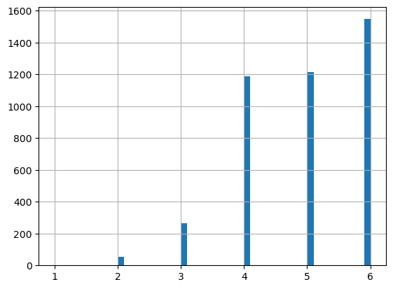

```python
# законченное образование
clean_df['edu'].hist(bins=50)
```

```python
clean_df['edu'].value_counts()
```

```
edu
6.00    1547
5.00    1214
4.00    1186
3.00     265
2.00      56
1.00       2
Name: count, dtype: int64
```

```python
clean_df[clean_df['edu'] == 1]['salary'] # гипотеза о том, что у респондентов с неоконченным средним образованием нет зп отклонена
```

```
602    13000.00
1618   16000.00
Name: salary, dtype: float64
```

```python
# базовая переменная - неоконченное среднее общее и ниже
clean_df['secondary_edu'] = clean_df['edu'].apply(lambda x: 1 if x == 4 else 0) # среднее общее
clean_df['proff_edu'] = clean_df['edu'].apply(lambda x: 1 if x == 5 else 0) # среднее профессиональное
clean_df['high_edu'] = clean_df['edu'].apply(lambda x: 1 if x == 6 else 0) # высшее
```

#### Место рождения

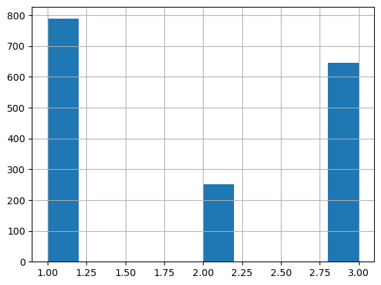

```python
# место рождения 1- город, 2 - ПГТ, 3 - деревня,село
clean_df['birthplace'].hist()
```

```python
# поставим в места пропуска тип населённого пункта, в котором живёт респондент на даный момент
clean_df.loc[((clean_df['locality'] == 1) | (clean_df['locality'] == 2)) & (clean_df['birthplace'].isna() == True), 'birthplace'] = 1
clean_df.loc[(clean_df['locality'] == 3) & (clean_df['birthplace'].isna() == True), 'birthplace'] = 2
clean_df.loc[(clean_df['locality'] == 4) & (clean_df['birthplace'].isna() == True), 'birthplace'] = 3
```

```python
clean_df['birthplace'].value_counts()
```

```
birthplace
1.00    2793
3.00    1063
2.00     422
Name: count, dtype: int64
```

#### Трудоустройство

```python
# трудоустройство 1 - работает, 2 - декретный отпуск, 3 - оплачиваемый отпуск, 4 - неоплачиваемый отпуск
clean_df['employment'].value_counts()
```

```
employment
1.00    4211
2.00      49
3.00      12
4.00       6
Name: count, dtype: int64
```

```python
# возьмём за базовую переменную тех кто работает
clean_df['maternity_leave'] = clean_df['employment'].apply(lambda x: 1 if x == 2 else 0) # декретный отпуск
clean_df['vacation'] = clean_df['employment'].apply(lambda x: 1 if x == 3 or x == 4 else 0) # отпуск
```

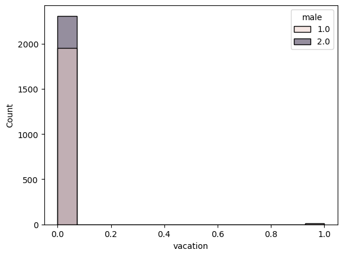

```python
sns.histplot(data=clean_df, x='vacation', hue='male')
```